# Generalized linear regression: logistic regression

## 1 Setup

**R**

Install packages if necessary.

```r
install.packages("marginaleffects")
install.packages("modelsummary")
install.packages("car")
install.packages("broom")
```

```r
library(marginaleffects)
library(modelsummary)
library(car)
library(broom)
```

Read in the dataset for the lecture and specify column classes (types).

```r
df <- read.csv("../data/polish-jvs.csv", colClasses = c("character", "factor", rep("character", 4), "numeric"))
head(df)
```

| id | woj | public | size | nace | nace_division | vacancies |
| --- | --- | --- | --- | --- | --- | --- |
| 27350 | 14 | 1 | Large | O | 84 | 2 |
| 26705 | 14 | 1 | Large | O | 84 | 1 |
| 257456 | 24 | 1 | Large | O | 84 | 2 |
| 183657 | 16 | 1 | Medium | O | 84 | 0 |
| 200042 | 18 | 1 | Medium | O | 84 | 0 |
| 26050 | 14 | 1 | Large | R | 91 | 4 |

**Python**

Load modules

```bash
!pip install statsmodels
```

```python
import pandas as pd
import numpy as np
import statsmodels.api as sm
import statsmodels.formula.api as smf
```

Read in the dataset for the lecture and specify column classes (types).

```python
df = pd.read_csv("../data/polish-jvs.csv", dtype={"id": np.int64, "woj":str, "public":str,"size": str, "nace_division": str, "nace": str})
df.head()
```

```
       id woj public    size nace nace_division  vacancies
0   27350  14      1   Large    O            84          2
1   26705  14      1   Large    O            84          1
2  257456  24      1   Large    O            84          2
3  183657  16      1  Medium    O            84          0
4  200042  18      1  Medium    O            84          0
```

**Julia**

```julia
using Pkg
Pkg.add(["Effects", "StatsBase", "CSV", "CategoricalArrays", "GLM"])
```

Load packages

```julia
using Effects
using StatsBase
using CSV
using CategoricalArrays
using GLM
using Statistics
using DataFrames
```

Read in the dataset for the lecture and specify column classes (types).

```julia
df=CSV.read("../data/polish-jvs.csv", DataFrame,
            types = Dict(:id => Int64, :woj=> String, :public=> String,
                         :size => String, :nace_division => String, :nace => String));
first(df, 5)
```

```
5×7 DataFrame
 Row │ id      woj     public  size    nace    nace_division  vacancies
     │ Int64?  String  String  String  String  String         Int64
─────┼──────────────────────────────────────────────────────────────────
   1 │  27350  14      1       Large   O       84                     2
   2 │  26705  14      1       Large   O       84                     1
   3 │ 257456  24      1       Large   O       84                     2
   4 │ 183657  16      1       Medium  O       84                     0
   5 │ 200042  18      1       Medium  O       84                     0
```

## 2 Example 1 – individual data

Create new variable

$$\text{Has vacancies} =
\begin{cases}
1 & \text{if has at least one vacancy},\\
0 & \text{otherwise}
\end{cases}$$

**R**

```r
df$has_vacancy <- df$vacancies > 0
df$size <- factor(df$size, c("Large", "Medium", "Small"))
```

Consider the following model

```r
model1 <- glm(formula = has_vacancy ~ public,
              data = df,
              family = binomial())
summary(model1)
```

```
Call:
glm(formula = has_vacancy ~ public, family = binomial(), data = df)

Deviance Residuals:
    Min       1Q   Median       3Q      Max
-0.5258  -0.5258  -0.4963  -0.4963   2.0761

Coefficients:
            Estimate Std. Error  z value Pr(>|z|)
(Intercept) -2.03197    0.01619 -125.492  < 2e-16 ***
public1      0.12312    0.02648    4.649 3.33e-06 ***
---
Signif. codes:  0 '***' 0.001 '**' 0.01 '*' 0.05 '.' 0.1 ' ' 1

(Dispersion parameter for binomial family taken to be 1)

    Null deviance: 42307  on 57479  degrees of freedom
Residual deviance: 42285  on 57478  degrees of freedom
AIC: 42289

Number of Fisher Scoring iterations: 4
```

Alternativelly, we may use `modelsummary` package and the same function

```r
modelsummary(model1, exponentiate = T, conf_level = 0.05,
             statistic  = NULL,
             estimate  = "{estimate} [{conf.low}, {conf.high}]")
```

|  | (1) |
| --- | --- |
| (Intercept) | 0.131 [0.131, 0.131] |
| public1 | 1.131 [1.129, 1.133] |
| Num.Obs. | 57480 |
| AIC | 42289.2 |
| BIC | 42307.1 |
| Log.Lik. | −21142.607 |
| F | 21.617 |
| RMSE | 0.33 |

Let’s write down this model

$$\operatorname{Pr}(\text { Has vacancy }=1 \mid \text { public })=\frac{\exp (-2.03+0.12 \times \text { public })}{1+\exp (-2.03+0.12 \times \text { public })}$$
In order to interpret results of logistic regression we should calculate odds ratio which can be done by just using $\exp(\mathbf{\beta})$

```r
exp(coef(model1))
```

```
(Intercept)     public1
  0.1310768   1.1310241
```

Interpretation of `1.13`:

- probability that a~*public* entity is 1.13 higher than the probability that a~private entity has a~vacancy.
- another interpretation: for 100 private entities with vacancies, we will have 113 public entities with vacancies

**Python**

```python
df["has_vacancy"] = np.where(df["vacancies"] > 0, True, False)
df["public"]=df["public"].astype("category")
mod1 = smf.glm(formula="has_vacancy ~ public", data=df, family=sm.families.Binomial()).fit()
print(mod1.summary())
```

```
                              Generalized Linear Model Regression Results
=======================================================================================================
Dep. Variable:     ['has_vacancy[False]', 'has_vacancy[True]']   No. Observations:                57480
Model:                                                     GLM   Df Residuals:                    57478
Model Family:                                         Binomial   Df Model:                            1
Link Function:                                           Logit   Scale:                          1.0000
Method:                                                   IRLS   Log-Likelihood:                -21143.
Date:                                         Sat, 06 May 2023   Deviance:                       42285.
Time:                                                 22:38:23   Pearson chi2:                 5.75e+04
No. Iterations:                                              5   Pseudo R-squ. (CS):          0.0003730
Covariance Type:                                     nonrobust
===============================================================================
                  coef    std err          z      P>|z|      [0.025      0.975]
-------------------------------------------------------------------------------
Intercept       2.0320      0.016    125.491      0.000       2.000       2.064
public[T.1]    -0.1231      0.026     -4.649      0.000      -0.175      -0.071
===============================================================================
```

**Julia**

```julia
df.has_vacancy = ifelse.(df.vacancies .> 0, true, false);
m1 = glm(@formula(has_vacancy ~ public), df, Binomial())
```

```
StatsModels.TableRegressionModel{GeneralizedLinearModel{GLM.GlmResp{Vector{Float64}, Binomial{Float64}, LogitLink}, GLM.DensePredChol{Float64, CholeskyPivoted{Float64, Matrix{Float64}, Vector{Int64}}}}, Matrix{Float64}}

has_vacancy ~ 1 + public

Coefficients:
────────────────────────────────────────────────────────────────────────────
                 Coef.  Std. Error        z  Pr(>|z|)   Lower 95%  Upper 95%
────────────────────────────────────────────────────────────────────────────
(Intercept)  -2.03197    0.016192   -125.49    <1e-99  -2.06371    -2.00024
public: 1     0.123124   0.0264817     4.65    <1e-05   0.0712203   0.175027
────────────────────────────────────────────────────────────────────────────
```

## 3 Example 2 – aggregated data

We show that it is possible to use aggregated data for logistic regression.

**R**

```r
df_aggregated <- aggregate(vacancies ~ has_vacancy + public, data = df, FUN = length) |>
  reshape(data = _, direction = "wide", idvar = c("public"), timevar = "has_vacancy", sep = "_")

df_aggregated
```

|  | public | vacancies_FALSE | vacancies_TRUE |
| --- | --- | --- | --- |
| 1 | 0 | 32912 | 4314 |
| 3 | 1 | 17639 | 2615 |

```r
model2 <- glm(formula = cbind(vacancies_TRUE, vacancies_FALSE) ~ public,
              data = df_aggregated,
              family = binomial())
summary(model2)
```

```
Call:
glm(formula = cbind(vacancies_TRUE, vacancies_FALSE) ~ public,
    family = binomial(), data = df_aggregated)

Deviance Residuals:
[1]  0  0

Coefficients:
            Estimate Std. Error  z value Pr(>|z|)
(Intercept) -2.03197    0.01619 -125.491  < 2e-16 ***
public1      0.12312    0.02648    4.649 3.33e-06 ***
---
Signif. codes:  0 '***' 0.001 '**' 0.01 '*' 0.05 '.' 0.1 ' ' 1

(Dispersion parameter for binomial family taken to be 1)

    Null deviance: 2.1446e+01  on 1  degrees of freedom
Residual deviance: 1.0784e-11  on 0  degrees of freedom
AIC: 23.653

Number of Fisher Scoring iterations: 2
```

**Python**

**Julia**

## 4 Example 3 – more variables

**R**

Consider the following model

```r
model3 <- glm(formula = has_vacancy ~ public + size + nace,
              data = df,
              family = binomial())
summary(model3)
```

```
Call:
glm(formula = has_vacancy ~ public + size + nace, family = binomial(),
    data = df)

Deviance Residuals:
    Min       1Q   Median       3Q      Max
-0.8963  -0.5838  -0.4195  -0.2911   2.8629

Coefficients:
            Estimate Std. Error z value Pr(>|z|)
(Intercept) -2.59659    0.11867 -21.880  < 2e-16 ***
public1      0.30889    0.04831   6.393 1.62e-10 ***
sizeMedium  -0.75403    0.03398 -22.189  < 2e-16 ***
sizeSmall   -1.38640    0.04697 -29.517  < 2e-16 ***
naceB        0.24733    0.21622   1.144 0.252668
naceC        1.43090    0.12151  11.776  < 2e-16 ***
naceD        0.76564    0.16502   4.640 3.49e-06 ***
naceE        0.53758    0.13864   3.878 0.000106 ***
naceF        1.20840    0.12837   9.413  < 2e-16 ***
naceG        0.91364    0.12522   7.296 2.96e-13 ***
naceH        1.24983    0.13008   9.608  < 2e-16 ***
naceI        1.16894    0.13630   8.576  < 2e-16 ***
naceJ        1.37829    0.13532  10.185  < 2e-16 ***
naceK        0.20644    0.14866   1.389 0.164931
naceL        0.97069    0.13502   7.189 6.53e-13 ***
naceM        1.03759    0.13159   7.885 3.14e-15 ***
naceN        0.77784    0.14008   5.553 2.81e-08 ***
naceO        1.58327    0.12382  12.787  < 2e-16 ***
naceP       -0.09844    0.12360  -0.796 0.425790
naceQ        0.91758    0.12456   7.367 1.75e-13 ***
naceR        0.66918    0.13490   4.961 7.02e-07 ***
naceS        1.21256    0.16809   7.214 5.44e-13 ***
---
Signif. codes:  0 '***' 0.001 '**' 0.01 '*' 0.05 '.' 0.1 ' ' 1

(Dispersion parameter for binomial family taken to be 1)

    Null deviance: 42307  on 57479  degrees of freedom
Residual deviance: 39042  on 57458  degrees of freedom
AIC: 39086

Number of Fisher Scoring iterations: 5
```

Now, the interpretation becomes more complex, so it is better to look at plots.

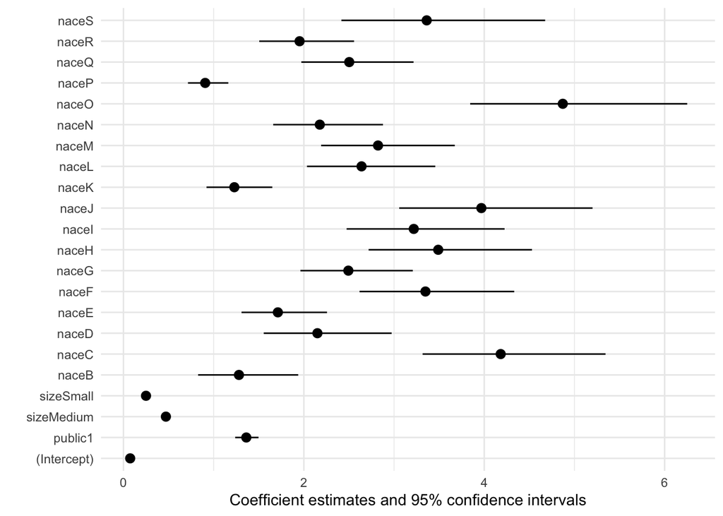

```r
modelplot(model3, exponentiate = T)
```

Additionally we can check whether a~given variable as a whole is “significant” using `car::Anova(type=2)`

```r
car::Anova(model3, type = 2) |> broom::tidy()
```

| term | statistic | df | p.value |
| --- | --- | --- | --- |
| public | 40.79875 | 1 | 0 |
| size | 1262.93059 | 2 | 0 |
| nace | 1431.50608 | 18 | 0 |

**Python**

```python
mod3 = smf.glm(formula="has_vacancy ~ public + size + nace", data=df, family=sm.families.Binomial()).fit()
print(mod3.summary())
```

```
                              Generalized Linear Model Regression Results
=======================================================================================================
Dep. Variable:     ['has_vacancy[False]', 'has_vacancy[True]']   No. Observations:                57480
Model:                                                     GLM   Df Residuals:                    57458
Model Family:                                         Binomial   Df Model:                           21
Link Function:                                           Logit   Scale:                          1.0000
Method:                                                   IRLS   Log-Likelihood:                -19521.
Date:                                         Sat, 06 May 2023   Deviance:                       39042.
Time:                                                 22:39:38   Pearson chi2:                 5.81e+04
No. Iterations:                                              6   Pseudo R-squ. (CS):            0.05522
Covariance Type:                                     nonrobust
==================================================================================
                     coef    std err          z      P>|z|      [0.025      0.975]
----------------------------------------------------------------------------------
Intercept          2.5966      0.119     21.871      0.000       2.364       2.829
public[T.1]       -0.3089      0.048     -6.393      0.000      -0.404      -0.214
size[T.Medium]     0.7540      0.034     22.188      0.000       0.687       0.821
size[T.Small]      1.3864      0.047     29.513      0.000       1.294       1.478
nace[T.B]         -0.2473      0.216     -1.144      0.253      -0.671       0.177
nace[T.C]         -1.4309      0.122    -11.771      0.000      -1.669      -1.193
nace[T.D]         -0.7656      0.165     -4.639      0.000      -1.089      -0.442
nace[T.E]         -0.5376      0.139     -3.876      0.000      -0.809      -0.266
nace[T.F]         -1.2084      0.128     -9.410      0.000      -1.460      -0.957
nace[T.G]         -0.9136      0.125     -7.294      0.000      -1.159      -0.668
nace[T.H]         -1.2498      0.130     -9.605      0.000      -1.505      -0.995
nace[T.I]         -1.1689      0.136     -8.574      0.000      -1.436      -0.902
nace[T.J]         -1.3783      0.135    -10.182      0.000      -1.644      -1.113
nace[T.K]         -0.2064      0.149     -1.388      0.165      -0.498       0.085
nace[T.L]         -0.9707      0.135     -7.187      0.000      -1.235      -0.706
nace[T.M]         -1.0376      0.132     -7.882      0.000      -1.296      -0.780
nace[T.N]         -0.7778      0.140     -5.551      0.000      -1.052      -0.503
nace[T.O]         -1.5833      0.124    -12.782      0.000      -1.826      -1.341
nace[T.P]          0.0984      0.124      0.796      0.426      -0.144       0.341
nace[T.Q]         -0.9176      0.125     -7.364      0.000      -1.162      -0.673
nace[T.R]         -0.6692      0.135     -4.959      0.000      -0.934      -0.405
nace[T.S]         -1.2126      0.168     -7.212      0.000      -1.542      -0.883
==================================================================================
```

**Julia**

```julia
m3 = glm(@formula(has_vacancy ~ public + size + nace), df, Binomial())
```

```
StatsModels.TableRegressionModel{GeneralizedLinearModel{GLM.GlmResp{Vector{Float64}, Binomial{Float64}, LogitLink}, GLM.DensePredChol{Float64, CholeskyPivoted{Float64, Matrix{Float64}, Vector{Int64}}}}, Matrix{Float64}}

has_vacancy ~ 1 + public + size + nace

Coefficients:
─────────────────────────────────────────────────────────────────────────────
                   Coef.  Std. Error       z  Pr(>|z|)   Lower 95%  Upper 95%
─────────────────────────────────────────────────────────────────────────────
(Intercept)   -2.59659     0.118674   -21.88    <1e-99  -2.82919    -2.36399
public: 1      0.308886    0.0483147    6.39    <1e-09   0.21419     0.403581
size: Medium  -0.754028    0.0339827  -22.19    <1e-99  -0.820633   -0.687423
size: Small   -1.3864      0.0469701  -29.52    <1e-99  -1.47846    -1.29434
nace: B        0.247331    0.216218     1.14    0.2527  -0.176449    0.671111
nace: C        1.4309      0.121512    11.78    <1e-31   1.19274     1.66906
nace: D        0.765645    0.165017     4.64    <1e-05   0.442217    1.08907
nace: E        0.537583    0.13864      3.88    0.0001   0.265854    0.809312
nace: F        1.2084      0.128375     9.41    <1e-20   0.956791    1.46001
nace: G        0.913636    0.125219     7.30    <1e-12   0.668212    1.15906
nace: H        1.24983     0.130084     9.61    <1e-21   0.994876    1.50479
nace: I        1.16894     0.136297     8.58    <1e-17   0.901799    1.43607
nace: J        1.37829     0.13532     10.19    <1e-23   1.11307     1.64352
nace: K        0.20644     0.14866      1.39    0.1649  -0.0849275   0.497809
nace: L        0.970686    0.135024     7.19    <1e-12   0.706044    1.23533
nace: M        1.03759     0.131588     7.89    <1e-14   0.779679    1.2955
nace: N        0.777842    0.140079     5.55    <1e-07   0.503291    1.05239
nace: O        1.58327     0.12382     12.79    <1e-36   1.34059     1.82596
nace: P       -0.0984383   0.123602    -0.80    0.4258  -0.340693    0.143816
nace: Q        0.91758     0.124555     7.37    <1e-12   0.673456    1.1617
nace: R        0.669184    0.134896     4.96    <1e-06   0.404793    0.933575
nace: S        1.21256     0.168086     7.21    <1e-12   0.883116    1.542
─────────────────────────────────────────────────────────────────────────────
```